# The Couch Economy

Wealth, Inactivity, and the Global NCD Burden

Ayange Ayangeakaa

April 6, 2026

## The Paradox

> As countries get richer, their populations stop moving.
- High incomes bring sedentary jobs, car-dependent cities, and screen-based leisure
- The result: rising obesity, diabetes, and premature NCD mortality
- **The Couch Economy** is an interactive dashboard that makes this paradox visible and explorable across 195 countries

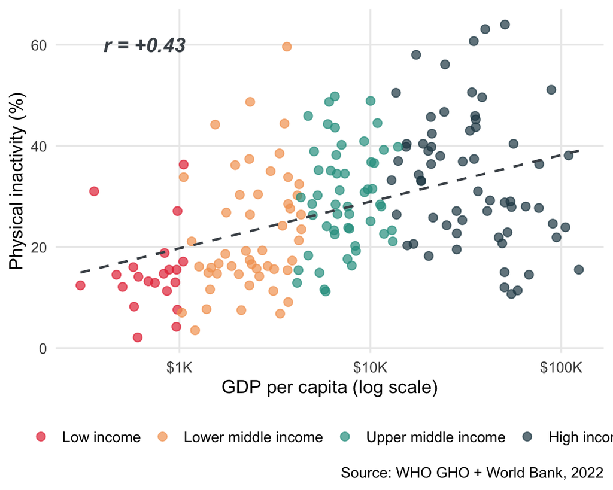

## The Income Gap

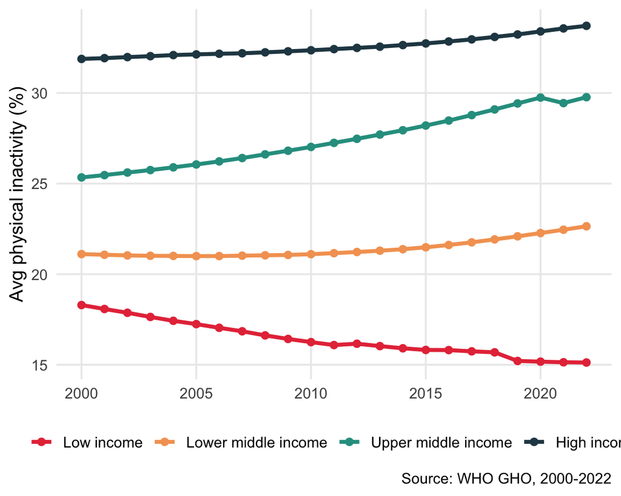

- High-income countries average **33.7%** inactivity
- Low-income countries average **15.1%**
- The gap: **18.6 percentage points**
- And it’s been **widening** over two decades
- This isn’t random — it’s structural

## Data Pipeline

| Stage | Script | What happens |
| --- | --- | --- |
| **Ingest** | `R/fetch_data.R` | Fetch 5 indicators from 3 APIs |
| **Process** | `R/process_data.R` | Clean, standardise, join on ISO-3 x year x sex |
| **Serve** | `app.R` | Interactive Shiny dashboard |
| **Generate** | `R/generate_brief.R` | On-demand country briefs via Gemini |
| **Automate** | `.github/workflows/refresh.yml` | Weekly cron: fetch, process, redeploy |

**Data sources:**

| Source | Indicators |
| --- | --- |
| WHO GHO | Inactivity, diabetes, NCD mortality |
| World Bank | GDP per capita, Gini, income group |
| OWID | Obesity prevalence |

**Final dataset:** 195 countries, 23 years, 3 sex categories = **13,455 rows**

## Three Capabilities

### API Integration

- **WHO GHO** OData API with pagination handler
- **World Bank** via `wbstats` R package
- **OWID** programmatic CSV
- 5 indicators from 3 sources
- No manual downloads

### GenAI Model

- **Google Gemini** 2.5 Flash Lite
- Generates 200-word country health briefs
- Two tones: *policy* vs *general public*
- Cached by country + data hash + tone
- Functional work, not decoration

### Automation

- **GitHub Actions** cron every Monday 06:00 UTC
- Full pipeline: fetch, process, commit, redeploy
- Stale brief cache invalidated automatically
- Zero manual intervention
- Self-healing: rebases on any intervening commits

## Data Wrangling Challenges

| Challenge | Solution |
| --- | --- |
| Three APIs use different country code schemes | `countrycode` package standardises everything to ISO-3 |
| WHO diabetes API returns **two age groups** (18+ and 30+), silently doubling rows on join | Filter to `AGEGROUP_YEARS18-PLUS` before joining |
| World Bank Gini index has ~15% missing values | Forward/backward fill within country (`tidyr::fill`) |
| WHO regional codes (`AFR`, `AMR`, `EMR`, `EUR`, `WPR`) mixed in with country data | `countrycode` returns `NA` for non-countries; filtered out |
| Venezuela and Ethiopia lack World Bank income classifications | Excluded from scatter plot; kept in trends and briefs |
| Trend chart had mismatched scales (inactivity vs NCD outcome) | Rebuilt with native plotly dual y-axis instead of ggplot2 rescaling |

## Live Demo

[ayange.shinyapps.io/couch-economy](https://ayange.shinyapps.io/couch-economy/)

Scatter plot | Trend chart | Country briefs | Downloads

## Design Decisions

| Decision | Rationale |
| --- | --- |
| Dual y-axis trend chart (native plotly) | Inactivity and NCD outcomes have different scales; rescaling to one axis produced misleading tooltips |
| GDP-inactivity correlation in value box | Communicates the project’s thesis in a single number that updates with filters |
| Cached Gemini briefs (country + hash + tone) | Avoids redundant API calls; instant on repeat visits; auto-invalidates when data changes |
| `bslib` + Bootstrap 5 layout | Responsive on mobile and desktop without custom CSS framework |
| OLS trend line on scatter | Makes the positive GDP-inactivity relationship immediately visible to non-technical users |
| Year as dropdown (not slider) | Consistent with other filter inputs; faster to select a specific year |

## Limitations and Future Work

### Limitations

- WHO inactivity estimates are **modelled**, not directly measured — confidence intervals are wide for some countries
- Gini forward-fill assumes inequality changes slowly — may miss abrupt economic shifts
- **Correlation is not causation** — the scatter shows association, not a causal mechanism
- Gemini briefs can occasionally overinterpret sparse data for small countries

### Future Work

- **Regional comparison panel** — compare Sub-Saharan Africa vs Europe side by side
- **Time animation** on the scatter plot to show how the paradox has evolved since 2000
- **Country comparison mode** — select two countries and see trends overlaid
- **WHO STEPS microdata** integration for countries with primary survey data
- **Confidence interval bands** on the trend chart using WHO’s `Low` and `High` columns

## Thank You

[ayange.shinyapps.io/couch-economy](https://ayange.shinyapps.io/couch-economy/)

**Source code**

github.com/aayange/couch-economy

**Course**

GLHLTH 562 — Spring 2026 Duke University